# Problem Statement

The purpose is to predict whether the Pima Indian women shows signs of diabetes or not. We are using a dataset collected by "National Institute of Diabetes and Digestive and Kidney Diseases" which consists of a number of attributes which would help us to perform this prediction.

**Constraints on data collection**

All patients whose data has been collected are females at least 21 years old of Pima Indian heritage

```python
#Import all the necessary modules
import matplotlib.pyplot as plt
import pandas as pd
from sklearn.tree import DecisionTreeClassifier
#importing seaborn for statistical plots
import seaborn as sns
#Let us break the X and y dataframes into training set and test set. For this we will use
#Sklearn package's data splitting function which is based on random function
from sklearn.model_selection import train_test_split
import numpy as np
# calculate accuracy measures and confusion matrix
from sklearn import metrics
```

# Q1. Load the PIMA Indian Diabetes file into Python DataFrame.

The file can be accessed directly from the URL (https://archive.ics.uci.edu/ml/machine-learning-databases/pima-indians-diabetes/pima-indians-diabetes.data or you may first download it to a local folder and then load it into Python dataframe. Let us assume the data frame is named pima_df

```python
pima_df = pd.read_csv("pima-indians-diabetes.csv")
```

# Q2. Print 10 samples from the dataset

```python
pima_df.head(10)
```

|  | Preg | Plas | Pres | skin | test | mass | pedi | age | class |
| --- | --- | --- | --- | --- | --- | --- | --- | --- | --- |
| 0 | 6 | 148 | 72 | 35 | 0 | 33.6 | 0.627 | 50 | 1 |
| 1 | 1 | 85 | 66 | 29 | 0 | 26.6 | 0.351 | 31 | 0 |
| 2 | 8 | 183 | 64 | 0 | 0 | 23.3 | 0.672 | 32 | 1 |
| 3 | 1 | 89 | 66 | 23 | 94 | 28.1 | 0.167 | 21 | 0 |
| 4 | 0 | 137 | 40 | 35 | 168 | 43.1 | 2.288 | 33 | 1 |
| 5 | 5 | 116 | 74 | 0 | 0 | 25.6 | 0.201 | 30 | 0 |
| 6 | 3 | 78 | 50 | 32 | 88 | 31.0 | 0.248 | 26 | 1 |
| 7 | 10 | 115 | 0 | 0 | 0 | 35.3 | 0.134 | 29 | 0 |
| 8 | 2 | 197 | 70 | 45 | 543 | 30.5 | 0.158 | 53 | 1 |
| 9 | 8 | 125 | 96 | 0 | 0 | 0.0 | 0.232 | 54 | 1 |

# Q3 Print the datatypes of each column and the shape of the dataset

```python
pima_df.info()
```

```
<class 'pandas.core.frame.DataFrame'>
RangeIndex: 768 entries, 0 to 767
Data columns (total 9 columns):
Preg     768 non-null int64
Plas     768 non-null int64
Pres     768 non-null int64
skin     768 non-null int64
test     768 non-null int64
mass     768 non-null float64
pedi     768 non-null float64
age      768 non-null int64
class    768 non-null int64
dtypes: float64(2), int64(7)
memory usage: 54.1 KB
```

```python
pima_df.shape
```

```
(768, 9)
```

```python
pima_df.describe().transpose()
```

|  | count | mean | std | min | 25% | 50% | 75% | max |
| --- | --- | --- | --- | --- | --- | --- | --- | --- |
| Preg | 768.0 | 3.845052 | 3.369578 | 0.000 | 1.00000 | 3.0000 | 6.00000 | 17.00 |
| Plas | 768.0 | 120.894531 | 31.972618 | 0.000 | 99.00000 | 117.0000 | 140.25000 | 199.00 |
| Pres | 768.0 | 69.105469 | 19.355807 | 0.000 | 62.00000 | 72.0000 | 80.00000 | 122.00 |
| skin | 768.0 | 20.536458 | 15.952218 | 0.000 | 0.00000 | 23.0000 | 32.00000 | 99.00 |
| test | 768.0 | 79.799479 | 115.244002 | 0.000 | 0.00000 | 30.5000 | 127.25000 | 846.00 |
| mass | 768.0 | 31.992578 | 7.884160 | 0.000 | 27.30000 | 32.0000 | 36.60000 | 67.10 |
| pedi | 768.0 | 0.471876 | 0.331329 | 0.078 | 0.24375 | 0.3725 | 0.62625 | 2.42 |
| age | 768.0 | 33.240885 | 11.760232 | 21.000 | 24.00000 | 29.0000 | 41.00000 | 81.00 |
| class | 768.0 | 0.348958 | 0.476951 | 0.000 | 0.00000 | 0.0000 | 1.00000 | 1.00 |

There are '0's in the data. Are they really valid '0's or they are missing values? Plasma, BP, skin thickness etc. these values cannot be 0. look at column by column logically to understand this.

# Q4 Replace all the 0s in the column with the median of the same column value accordingly.

```python
#pima_df.loc[:, 'Plas','Pres','skin','test'].replace(to_replace=0, value=pima_df.median(), inplace=True)
pima_df['Plas'].replace(to_replace=0, value=pima_df['Plas'].median(), inplace=True) #'Plas','Pres','skin','test'
pima_df['Pres'].replace(to_replace=0, value=pima_df['Pres'].median(), inplace=True)
pima_df['skin'].replace(to_replace=0, value=pima_df['skin'].median(), inplace=True)
pima_df['test'].replace(to_replace=0, value=pima_df['test'].median(), inplace=True)
pima_df['mass'].replace(to_replace=0, value=pima_df['mass'].median(), inplace=True)
```

# Q5 Print the descriptive statistics of each & every column using describe() function

```python
pima_df.describe().transpose()
```

|  | count | mean | std | min | 25% | 50% | 75% | max |
| --- | --- | --- | --- | --- | --- | --- | --- | --- |
| Preg | 768.0 | 3.845052 | 3.369578 | 0.000 | 1.00000 | 3.0000 | 6.00000 | 17.00 |
| Plas | 768.0 | 121.656250 | 30.438286 | 44.000 | 99.75000 | 117.0000 | 140.25000 | 199.00 |
| Pres | 768.0 | 72.386719 | 12.096642 | 24.000 | 64.00000 | 72.0000 | 80.00000 | 122.00 |
| skin | 768.0 | 27.334635 | 9.229014 | 7.000 | 23.00000 | 23.0000 | 32.00000 | 99.00 |
| test | 768.0 | 94.652344 | 105.547598 | 14.000 | 30.50000 | 31.2500 | 127.25000 | 846.00 |
| mass | 768.0 | 32.450911 | 6.875366 | 18.200 | 27.50000 | 32.0000 | 36.60000 | 67.10 |
| pedi | 768.0 | 0.471876 | 0.331329 | 0.078 | 0.24375 | 0.3725 | 0.62625 | 2.42 |
| age | 768.0 | 33.240885 | 11.760232 | 21.000 | 24.00000 | 29.0000 | 41.00000 | 81.00 |
| class | 768.0 | 0.348958 | 0.476951 | 0.000 | 0.00000 | 0.0000 | 1.00000 | 1.00 |

# Q6 See the distribution of 'Class' variable and plot it using appropriate graph.

```python
# Let us look at the target column which is 'class' to understand how the data is distributed amongst the various values
pima_df.groupby(["class"]).count()

# Most are not diabetic. The ratio is almost 1:2 in favor or class 0.  The model's ability to predict class 0 will
# be better than predicting class 1.
```

| class | Preg | Plas | Pres | skin | test | mass | pedi | age |
| --- | --- | --- | --- | --- | --- | --- | --- | --- |
| 0 | 500 | 500 | 500 | 500 | 500 | 500 | 500 | 500 |
| 1 | 268 | 268 | 268 | 268 | 268 | 268 | 268 | 268 |

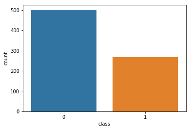

```python
sns.countplot(x='class', data=pima_df)
```

# Just for your understanding - Using univariate analysis check the individual attributes for their basic statistic such as central values, spread, tails etc. What are your observations (any two attributes). Its an optional step and will not be graded.

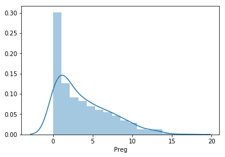

```python
sns.distplot(pima_df.Preg) # long right skewed tail
```

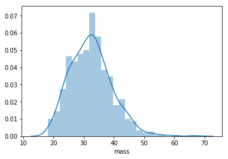

```python
sns.distplot(pima_df.mass) # good curve, closer to normal curve than some other attributes.
```